# Ablation planning with a neural cellular automaton

**MICCAI 2026 · Learning to Self-Organize · Hands-on 3** · Jonas Mehtali, University of Strasbourg / ICube

A microwave needle in the liver, a power, five minutes of heating. Which tissue dies? The physics answer couples Pennes bioheat, the microwave power deposition and an Arrhenius damage integral. The solvers from my PhD work (supervised by Prof. Caroline Essert and Juan Verde) take about **20 seconds** per plan, and they produced every label in this notebook.

In the next 30 minutes you will train an NCA with about **ten thousand parameters** that answers in milliseconds. From the same rollout it also segments the liver vessels, without ever being told where they are. Vessels carry heat away, so a model that gets the necrosis right near a vessel has to find the vessel first.

| 0 | setup | 2 min |
| --- | --- | --- |
| 1 | play with the finished model | 3 min |
| 2 | one case, inputs and targets | 2 min |
| 3 | build the automaton (TODO 1-5) | 8 min |
| 4 | train it | 5 min |
| 5 | how good is it? (TODO 6) | 5 min |
| 6 | your model in the planner, and breaking it | 5 min |

**Before anything else: Runtime → Change runtime type → T4 GPU.**

## 0 · Setup

```python
import os, sys, shutil, subprocess, pathlib, dataclasses

REPO = "https://github.com/JonasMht/miccai2026-nca-tutorial"
if "google.colab" in sys.modules and not pathlib.Path("miccai2026-nca-tutorial/ablation2d").exists():
    r = subprocess.run(["git", "clone", "--depth", "1", REPO], capture_output=True, text=True)
    if r.returncode != 0:
        raise RuntimeError("git clone failed:\n" + r.stderr.strip())

ROOT = next((p.resolve() for p in map(pathlib.Path, ("miccai2026-nca-tutorial/ablation2d", "ablation2d", ".", ".."))
             if (p / "ablation2d" / "channels.py").exists()), None)
if ROOT is None:
    raise RuntimeError("could not find the ablation2d package next to this notebook")
sys.path.insert(0, str(ROOT))

import numpy as np
import torch
import torch.nn as nn
import matplotlib.pyplot as plt

DEVICE = "cuda" if torch.cuda.is_available() else "cpu"
print("device:", torch.cuda.get_device_name(0) if DEVICE == "cuda" else "CPU (training will be slow)")

# the test harness (scripts/test_notebook.py) sets this to run on a CPU in minutes
QUICK = os.environ.get("NCA_NOTEBOOK_QUICK") == "1"
LIMIT = 48 if QUICK else None

# ablation2d holds the plumbing: data, plotting, the training loop.
# The parts that are the lesson are typed out in this notebook.
from ablation2d import viz
from ablation2d.data import AblationDataset
from ablation2d.anatomy import from_segmentations
from ablation2d.train import FAST, load_checkpoint
from ablation2d.webplanner import BrowserPlanner, slice_from_anatomy, slices_from_split

# plans with one or two needles, as in the planner
data = {s: AblationDataset(ROOT / "data_liver" / f"{s}.npz", device=DEVICE, limit=LIMIT, max_needles=2)
        for s in ("train", "val", "test")}
scanned = AblationDataset(ROOT / "data" / "test.npz", limit=LIMIT, max_needles=2)   # same cases, CT not masked
for s, d in data.items():
    print(f"{s:5s} {len(d):4d} plans")
```

```
device: NVIDIA GeForce RTX 4080 SUPER
```

```
train 2327 plans
val    314 plans
test   659 plans
```

## 1 · The finished model

This is the reference model, trained for 240 epochs on the same data you will use: 46,240 parameters, 5 blocks per step, 4 steps once the anatomy is read. Test DSC 0.907 on the necrosis and F1 0.838 on the vessels. It runs **in this page, on your GPU**: the weights were copied into a WebGL shader, so every edit reruns the whole rollout in a few milliseconds without going back to Python. The rollout stops at the number of steps chosen on validation, as the model is evaluated.

Things to try:

- drag the **white dot** to move the needle, the grey one to turn it;
- park the tip right next to a large vessel. The lesion is notched on that side: blood carries the heat away. Nobody told the model where the vessels are;
- **+ add a needle** (or double-click) for a second one, and set each power;
- press **replay growth** to watch the field grow from the needle, one local update at a time;
- turn on the **eraser** and wipe part of the lesion: the automaton repairs it;
- switch **patient**: these are test slices the model never saw.

```python
reference, ref_cfg, ref_ck = load_checkpoint(ROOT / "checkpoints" / "ablation_cnca_liver.pt", device=DEVICE)

real = np.load(ROOT / "data" / "real_slice.npz")
anat = from_segmentations(real["seg_liver"], real["seg_vessel"], hounsfield=real["hounsfield"])
slices = [slice_from_anatomy(anat, "demo slice")] + slices_from_split(scanned, data["test"], n=4)

BrowserPlanner([(f"reference, {ref_cfg.epochs} epochs", reference, ref_ck["vessel_threshold"], ref_cfg.infer_steps)],
               slices)
```

## 2 · One case

Each training case is a CT slice from a real patient, one to four needles and a power per needle. The corpus has 4 000 plans on 2 000 slices from 50 livers, split **by patient** so that no slice of a test liver was seen in training. We use the plans with one or two needles, 83 % of them, which is also what the planner allows.

The model gets three channels and must produce two:

| in |  | out |  |
| --- | --- | --- | --- |
| `hounsfield` | the CT, zeroed outside the liver | `cell_death` | Arrhenius damage |
| `needle` | the applicator shaft | `vessel` | where the vessels are |
| `applicator_activation` | power at the radiating slot |  |  |

**Why mask the CT to the liver?** Three quarters of the slice is bowel, spine, ribs and air, and for a ten-thousand-parameter model all of it is a distraction. Masking was one of the largest effects I measured: necrosis DSC 0.848 → 0.868 and vessel F1 0.611 → 0.749. It helps a plain Hounsfield threshold even more (vessel F1 0.245 → 0.439), so baselines are always scored on the same masked input.

Burn time is fixed at 5 minutes, so it is not an input. The label is solved in 3-D and then sliced: a one-voxel-thick 2-D solve is an infinite slab and gives lesions 14 % too long.

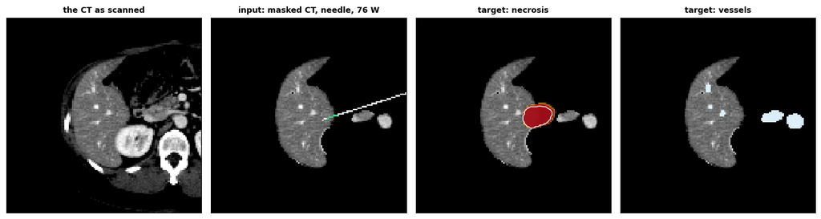

```
necrosis 9.1 cm²  ·  vessels on 1.3 % of the slice
```

```python
i = 3
x, y = data["test"].sample(i)
viz.show_case(x[0].cpu(), y[0].cpu(), hu_scanned=scanned.sample(i)[0][0, 0].numpy() * 2000 - 1000)
plt.show()
print(f"necrosis {(y[0, 0] >= 0.99).sum().item() * 0.04:.1f} cm²  ·  vessels on "
      f"{100 * y[0, 1].mean().item():.1f} % of the slice")
```

## 3 · The automaton

A **chained** NCA: one step runs $N$ small convolution blocks in sequence, each adding a residual update. The state is one tensor whose channels have jobs:

| channels | role | updated by the model? |
| --- | --- | --- |
| 0 - 1 | the answers: necrosis, vessels | yes |
| 2 - 4 | the environment: CT, needle, power | no, rewritten from the inputs after every step |
| 5 + | scratch space | yes |

Each block is two 3×3 convolutions, so information travels $2N$ cells per step. With 2 answers and 3 environment channels pinned, the scratch channels are the only place the model can compute: a 6-channel version (one scratch channel) scored necrosis DSC 0.30, and adding channels lifted **both** heads together.

**Anatomy first, then heat.** Where the vessels are does not depend on the needle. A single rollout that sees the plan while it looks for them learns a shortcut anyway: inside a lesion, it stops seeing vessels (on a single-phase model, 8 % of the vessel pixels inside the lesion were found, against 84 % away from it). So the rollout has two phases with the same rule: a few steps with the needle and power channels empty, which can only find the vessels from the CT, then the planned steps with the vessel answer held fixed, like the CT. The vessel map cannot depend on the plan, by construction.

Every cell updates at every step. The original Growing-NCA recipe lets each cell fire with probability ½ instead; on this task that measured worse (5-minute budget, three seeds: necrosis DSC 0.818 → 0.831 and vessel F1 0.674 → 0.715 without it), and without it the model is deterministic.

Fill in TODO 1 to 3 below. Everything else in the class is given, including the two phases in `forward`.

```python
N_OUT, N_INPUT = 2, 3
OUT = slice(0, N_OUT)                  # necrosis, vessels
ENV = slice(N_OUT, N_OUT + N_INPUT)    # CT, needle, power
STATE_CLAMP = 4.0
```

```python
class AblationCNCA(nn.Module):
    def __init__(self, channels=12, hidden_mult=2, n_sub_models=2, anatomy_steps=6):
        super().__init__()
        self.channels, self.n_sub_models = channels, n_sub_models
        self.anatomy_steps = anatomy_steps
        hidden = channels * hidden_mult
        self.sub_models = nn.ModuleList([
            nn.Sequential(
                nn.Conv2d(channels, hidden, 3, padding=1),
                nn.ReLU(),
                nn.Conv2d(hidden, channels, 3, padding=1, bias=False),
            ) for _ in range(n_sub_models)
        ])
        for sub in self.sub_models:
            fan_in = sub[0].weight[0].numel()
            nn.init.normal_(sub[0].weight, 0.0, (2.0 / fan_in) ** 0.5 * 0.1)
            nn.init.zeros_(sub[0].bias)
            nn.init.zeros_(sub[2].weight)          # every block starts as a no-op

    def step(self, x):
        for sub in self.sub_models:
            x = STATE_CLAMP * torch.tanh((x + sub(x)) / STATE_CLAMP)
        return x

    def seed(self, inputs):
        b, _, h, w = inputs.shape
        x = inputs.new_zeros(b, self.channels, h, w)
        x[:, ENV] = inputs
        return x

    def run(self, x, env, steps, hold=None, trace=None):
        # `steps` updates; after each one the environment is put back, and
        # `hold` (if given) is written back into the vessel channel
        for _ in range(steps):
            x = self.step(x)
            x = torch.cat([x[:, OUT], env, x[:, ENV.stop:]], dim=1)
            if hold is not None:
                x = torch.cat([x[:, :1], hold, x[:, 2:]], dim=1)
            if trace is not None:
                trace.append(torch.sigmoid(x[:, OUT]).detach())
        return x

    def forward(self, inputs, steps=8, state=None, return_trace=False, return_state=False):
        if state is None:
            if self.anatomy_steps:
                # phase 1, the anatomy: the needle is not in yet, so the vessels
                # are found from the CT alone
                ct_only = inputs.clone()
                ct_only[:, 1:] = 0
                state = self.run(self.seed(ct_only), ct_only, self.anatomy_steps)
            else:
                state = self.seed(inputs)
        # phase 2, the heating: the needle is on, the vessels found above are held
        hold = state[:, 1:2] if self.anatomy_steps else None
        trace = [] if return_trace else None
        x = self.run(state, inputs, steps, hold=hold, trace=trace)
        out = torch.sigmoid(x[:, OUT])
        if return_trace:
            return (out, trace, x) if return_state else (out, trace)
        return (out, x) if return_state else out


model = AblationCNCA(FAST.channels, FAST.hidden_mult, FAST.n_sub_models).to(DEVICE)
n_params = sum(p.numel() for p in model.parameters())
print(f"{n_params:,} parameters · {model.channels} channels = {N_OUT} answers + "
      f"{N_INPUT} environment + {model.channels - N_OUT - N_INPUT} scratch")
print(f"information travels {2 * model.n_sub_models} cells (= {4 * model.n_sub_models} mm) per step")
```

```
10,416 parameters · 12 channels = 2 answers + 3 environment + 7 scratch
information travels 4 cells (= 8 mm) per step
```

**A free check before training.** Every block's last convolution starts at zero, so the untrained model must output an *exactly* flat field. If it does not, the state layout or the step is wrong, and you find out in two seconds instead of after five minutes of training.

```python
with torch.no_grad():
    p = model(data["val"].sample(0)[0], steps=20)
spread = float(p.max() - p.min())
print(f"output {tuple(p.shape)}, spread {spread:.1e}:", "flat, good" if spread == 0 else "NOT flat")
```

```
output (1, 2, 128, 128), spread 0.0e+00: flat, good
```

### The loss

Necrosis covers 1 to 4 % of the slice, and an unweighted MSE is minimised by predicting nothing. So foreground cells weigh **100 : 1**: a missed necrotic cell costs as much as a hundred invented ones. For an ablation margin, over-predicting is the safer mistake, and that ratio is a clinical choice.

The vessels get Dice + weighted BCE, and the two are summed as `L = L_necrosis + w · L_vessel`. Remember that `w`, we come back to it.

```python
def necrosis_loss(pred, target, fg=100.0, bg=1.0, thr=0.01):
    w = torch.where(target > thr, torch.full_like(target, fg), torch.full_like(target, bg))
    return (w * (pred - target) ** 2).sum() / w.sum()
```

```python
# two cases you can check in your head
p_, t_ = torch.tensor([[[[0.0, 1.0]]]]), torch.tensor([[[[1.0, 1.0]]]])
assert abs(float(necrosis_loss(p_, t_)) - 0.5) < 1e-6      # weights 100, 100; errors 1, 0
t_ = torch.tensor([[[[1.0, 0.0]]]])
assert abs(float(necrosis_loss(p_, t_)) - 1.0) < 1e-6      # weights 100, 1; errors 1, 1
print("necrosis_loss is correct")
```

```
necrosis_loss is correct
```

## 4 · Training

The loop is imported, it is plumbing. The tricks from the talk are inside it, each marked `# TRICK n` in `ablation2d/train.py`: a random rollout length per batch, starting some batches from states the model reaches on its own, per-parameter gradient normalisation, and persistence (a second, longer stretch of the same rollout is supervised too, so the field holds when you keep iterating, which the planner relies on).

The budget is **5 minutes of wall clock**, not a number of epochs, so it works on any GPU. The learning rate follows the clock and the best validation epoch is kept.

Four settings below were measured, not guessed:

- `lr = 5e-3`, higher than the long recipe uses. With only about fifteen epochs to spend, it gave the vessel head +0.07 F1 over three seeds, for no measurable cost on the necrosis.
- `vessel_weight = 0.3`. At 3.0 the necrosis term received only 3 % of the loss, and moving this one number took validation DSC at epoch 10 from 0.46 to 0.79. You will see the shares on your own model in section 5.
- `ema_decay = 0.99`: the model that is kept is a running average of the weights, which is less noisy than the last step. Together with the one-or-two-needle plans, it took the 5-minute model from DSC 0.83 to 0.86.
- `augment_d4 = False`. Rotations and flips look free for a diffusion problem, but these are axial CT slices in a standard orientation. With augmentation the vessel head fell from F1 0.70 to 0.28 while the necrosis did not move.

No GPU? Set `LOAD_PRETRAINED = True` to load the reference model instead.

```python
from ablation2d.train import train
from ablation2d.live import LiveDashboard

LOAD_PRETRAINED = os.environ.get("NCA_NOTEBOOK_PRETRAINED") == "1"   # set True to skip training

cfg = dataclasses.replace(FAST, device=DEVICE, lr=5e-3, vessel_weight=0.3, augment_d4=False,
                          anatomy_steps=model.anatomy_steps, ema_decay=0.99,
                          epochs=24, warmup_epochs=2, validate_every=2, time_budget_s=5 * 60)
if QUICK:
    cfg = dataclasses.replace(cfg, epochs=2, validate_every=1, time_budget_s=None)

if LOAD_PRETRAINED:
    model, cfg, _ = load_checkpoint(ROOT / "checkpoints" / "ablation_cnca_liver.pt", device=DEVICE)
else:
    dash = LiveDashboard(data["val"], steps=cfg.infer_steps, budget_s=cfg.time_budget_s)
    model, history = train(cfg, data["train"], data["val"], model=model, on_epoch=dash,
                           select="both", log=lambda *a: None)
```

1. Which head converges first, necrosis or vessels? Why would one be harder?
2. Which of the three inputs matters most? Guess now, then check in the planner in section 6 by setting a needle to 0 W.
3. It is trained with rollouts of 3 to 10 steps. What happens at 400?

## 5 · How good is it?

The number of steps at inference is a free choice that training does not fix. Pick it on validation, and take the cheapest value within 1 % of the best.

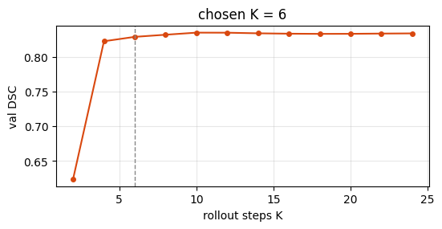

```python
from ablation2d.train import choose_inference_steps

K, scores = choose_inference_steps(model, data["val"], candidates=range(2, 25, 2))
cfg = dataclasses.replace(cfg, infer_steps=K)

plt.figure(figsize=(6, 2.6), dpi=100)
plt.plot(list(scores), list(scores.values()), "-o", ms=4, color="#d9480f")
plt.axvline(K, color="#888", ls="--", lw=1)
plt.xlabel("rollout steps K"); plt.ylabel("val DSC"); plt.title(f"chosen K = {K}")
plt.grid(alpha=0.3); plt.show()
```

Now the test set, against two baselines that do not need a network:

- **the device chart**: a sphere sized from power and time, which is roughly what the manufacturer's table gives a clinician. It ignores the anatomy, so beating it means the model learned something about the anatomy;
- **the best Hounsfield threshold** for the vessels, fitted on the split it is scored on. Contrast-enhanced vessels are bright, so `hu > t` is a working segmenter.

The vessel threshold is chosen on validation, like K.

```python
import pandas as pd
from ablation2d.evaluate import fit_sphere_baseline, predict_all, report, sphere_baseline, hu_threshold_vessel_f1
from ablation2d.model import best_vessel_threshold

sphere = fit_sphere_baseline(data["train"])
with torch.no_grad():
    vthr, _ = best_vessel_threshold(predict_all(model, data["val"], K), data["val"].targets)

def row(r):
    return {"necrosis DSC": r.get("dice"), "area error cm²": r.get("area_err_cm2"),
            "recall": r.get("recall"), "precision": r.get("precision"), "vessel F1": r.get("vessel_f1")}

one = report(model, data["test"], steps=K, vessel_threshold=vthr,
             baselines={"device chart": lambda x: sphere_baseline(x, sphere)})
table = pd.DataFrame({"your model": row(one["C-NCA"]),
                      "device-chart sphere": row(one["device chart"]),
                      "best HU threshold": {"vessel F1": hu_threshold_vessel_f1(data["test"])}}).T
table.style.format(precision=3, na_rep="")
```

|  | necrosis DSC | area error cm² | recall | precision | vessel F1 |
| --- | --- | --- | --- | --- | --- |
| your model | 0.833 | 3.187 | 0.974 | 0.726 | 0.777 |
| device-chart sphere | 0.793 | 4.279 | 0.972 | 0.667 |  |
| best HU threshold |  |  |  |  | 0.435 |

**Read recall against precision.** Recall above precision means the model over-predicts the zone, which is what the 100 : 1 weighting asked for. The reference model scores DSC 0.907 and vessel F1 0.838 on the same split.

### Check the share, not the weight

The two loss terms live on different scales. Here is how much of the total the necrosis head actually receives on your model, at three weights.

```python
from ablation2d.model import soft_dice_loss, masked_bce

xb, yb = data["val"].sample(slice(0, 16))
with torch.no_grad():
    p = model(xb, steps=K)
l_nec = float(necrosis_loss(p[:, :1], yb[:, :1]))
l_ves = float(soft_dice_loss(p[:, 1:], yb[:, 1:]) + masked_bce(p[:, 1:], yb[:, 1:], 20.0))
for w in (3.0, 1.0, 0.3):
    print(f"w = {w:3.1f}   necrosis gets {100 * l_nec / (l_nec + w * l_ves):4.1f} % of the loss")
```

```
w = 3.0   necrosis gets  2.9 % of the loss
w = 1.0   necrosis gets  8.3 % of the loss
w = 0.3   necrosis gets 23.1 % of the loss
```

### The second head

Best, median and worst test cases for the vessel head. Green is vessel found, blue missed, red invented. Expect the large vessels to be found and the fine branches to be missed: that is where most of the remaining error is.

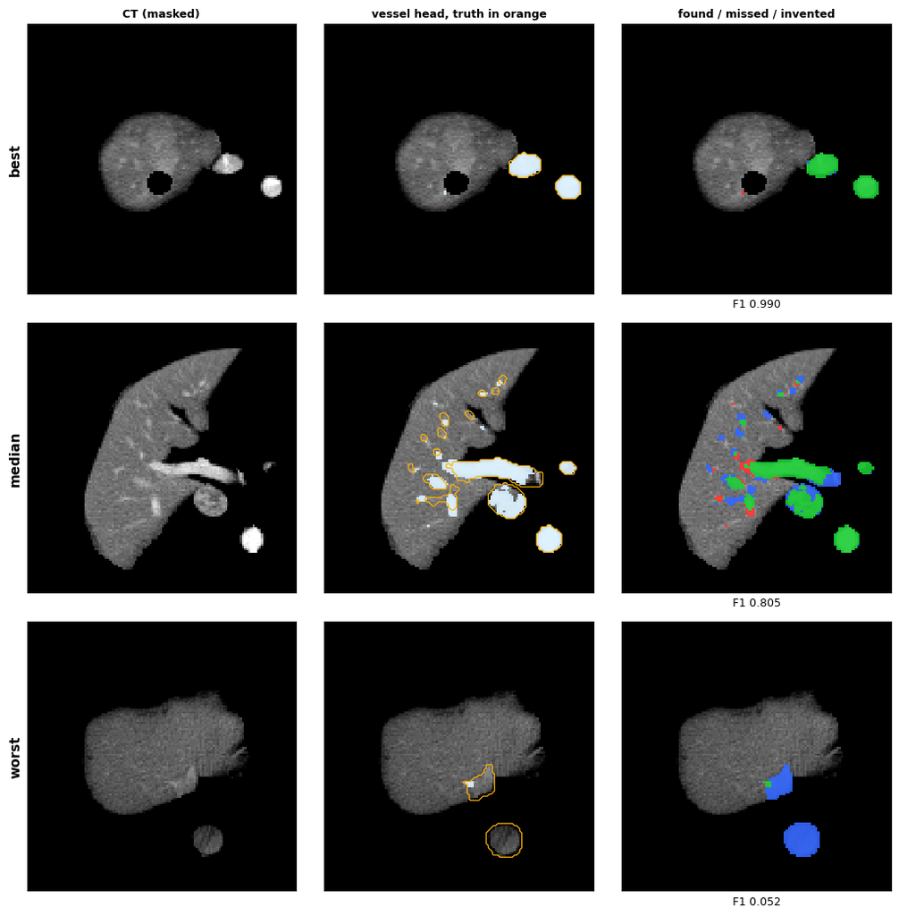

```python
from ablation2d.model import vessel_f1

with torch.no_grad():
    pt = predict_all(model, data["test"], K)
per = vessel_f1(pt, data["test"].targets, vthr)
order = torch.argsort(per, descending=True)
pick = [int(order[0]), int(order[len(order) // 2]), int(order[-1])]
viz.vessel_gallery([data["test"].sample(k)[0][0, 0].cpu() for k in pick],
                   [data["test"].targets[k, 1].cpu() for k in pick],
                   [pt[k, 1].cpu() for k in pick], vthr, f1=[float(per[k]) for k in pick])
plt.show()
```

## 6 · Your model in the planner

Both models are in the **model** menu now: yours after five minutes, and the reference after 240 epochs. Same slices, same needles.

Try to break them. Predict what happens before you try each one:

- **Too much power.** The corpus was sampled between 30 and 150 W. Scroll a needle up to 250 W.
- **Outside the liver.** Drag the tip into the stomach or beside the spine. The model was never shown a tip there, and with the masked CT it cannot see the tissue it would be burning.
- **Carry the state across edits.** Tick it, then move the needle. The rollout now continues from the old answer instead of the blank seed. The model was trained to *hold* an answer once it has one: how far does the lesion follow?
- **Look inside.** In the **show** menu pick a scratch channel (5 and up). These have no units and nobody told them what to do.

No live view (an old browser without WebGL2)? `AblationStudio` from `ablation2d.ui` is the same planner with sliders, rendered in Python.

```python
BrowserPlanner([("your model, 5 minutes", model, vthr, K),
                (f"reference, {ref_cfg.epochs} epochs", reference, ref_ck["vessel_threshold"], ref_cfg.infer_steps)],
               slices)
```

One number to go with the "keep state" experiment: the same rollout run far past the lengths it was trained on.

```python
from ablation2d.model import dice

xb, yb = data["test"].sample(slice(0, 32))
with torch.no_grad():
    for k in (K, 30, 100, 400):
        print(f"K = {k:3d}   DSC {float(dice(model(xb, steps=k), yb).mean()):.3f}")
```

```
K =   6   DSC 0.844
K =  30   DSC 0.843
```

```
K = 100   DSC 0.843
```

```
K = 400   DSC 0.844
```

## What to take away

- **Heat diffusion is a local rule iterated in time, and so is an NCA.** That match is why ten thousand parameters can stand in for a 20-second solve.
- **One rule, two outputs.** The same rollout predicts the necrosis and segments the vessels it needs, from a CT, a needle and a power.
- **Freeze what must not depend on the plan.** Found from the CT alone and then held fixed, the vessel map cannot be bent by the lesion; seen together with the plan, the model had learned to stop seeing vessels inside a lesion.
- **Scratch channels are where it computes.** Answers and environment are pinned; width went into both heads at once.
- **Check the share, not the weight.** A loss weight of 3.0 looked harmless and gave one head 3 % of the loss.
- **Show the model what matters, and measure the tricks.** Masking the CT helped both heads; augmentation, which looked free, cost the vessel head most of its F1.
- **A surrogate is only as good as its labels.** The device calibration behind every label here is provisional: fitted on ex vivo bovine liver at 17 °C, held-out error 9.9 %, not clinically validated.

**Going further:** predict peak temperature and read the 50 °C isotherm; condition on a tumour mask and report the margin; put the surrogate inside an optimiser and search for the plan, which is what the 3-D version does.

**Reading:** Mehtali, Verde & Essert, *C-NCA* (MICCAI 2025) — the paper behind this hands-on · Mehtali, Verde & Essert, *Heat* (IJCARS 2025) — the 3-D solver that made the labels · Kalkhof, González & Mukhopadhyay, *Med-NCA* (IPMI 2023, TU Darmstadt) · Mordvintsev et al., *Growing Neural Cellular Automata* (Distill 2020) · Pennes (1948) · Lu et al., *AJR* (2002) on the vessel heat sink.

Code, both notebooks and the slides: https://github.com/JonasMht/miccai2026-nca-tutorial